### Part II

#### Solution

Tuesday, May 20, 2014

**2.** A researcher (call him Soren) is interested in what factors in influence human reaction time to a visual stimulus. In his first study, Soren recruited 88 subjects from a local shopping mall, age 16 to 70, asked them their gender, age, race, and years of education, and had them take a test of reaction time. Data can be found in the file `reaction_time.txt`.

Note: All the data in this question are fictitious, produced by a simulation program, but you should treat the data as if it were real.

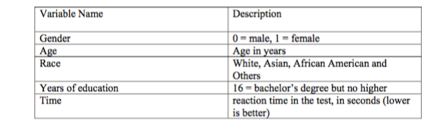

For all of the following parts, you must include any pertinent SAS (or R) code for full credit.

```r
# Read in data
raw.text <- "
sex    age education race reaction_time
1   22  10  white   33.4
0   25  16  white   39.2
0   23  16  Asian   38.8
0   24  17  African 34.8
0   22  15  Other   35.1
0   23  16  African 31.6
1   29  22  Asian   40.1
1   27  16  white   38.2
1   22  11  white   31.1
1   25  18  Asian   36.5
1   23  16  Asian   28.7
0   24  17  African 36.3
0   22  15  Other   36.3
0   23  16  African 38.1
0   29  20  Other   43.5
0   27  16  white   33.6
1   23  16  African 42.4
1   30  16  white   39.4
1   33  10  Asian   38.2
1   35  16  Asian   45.7
1   34  18  African 52.4
0   37  21  Other   52.3
0   37  21  African 51.7
0   39  16  white   51.8
0   39  16  Asian   47.6
0   30  12  Asian   36.6
1   33  12  African 36.6
1   35  12  Other   51.4
1   34  16  white   47.4
1   37  18  Asian   46.4
1   37  21  Asian   50.8
0   39  18  African 49.9
0   39  18  Other   47.5
0   31  12  African 38.0
0   31  12  Other   35.9
0   33  16  Other   40.3
1   40  16  Asian   51.3
1   41  16  white   49.0
1   44  18  white   55.5
1   45  16  Asian   65.2
1   45  18  Asian   60.4
0   46  21  African 64.7
0   48  21  Other   61.2
0   49  16  African 66.0
0   49  16  Other   59.0
0   44  12  white   51.7
1   43  12  white   56.8
1   40  12  Asian   45.7
1   41  16  African 57.2
1   44  18  Other   58.7
1   45  21  Other   61.8
0   45  18  Asian   62.2
0   46  18  white   56.1
0   48  12  white   56.7
0   49  12  Asian   55.1
0   49  16  Asian   67.2
1   44  16  African 54.6
1   43  16  Other   51.2
1   43  18  African 46.2
1   50  16  Other   53.5
1   51  18  white   62.1
0   54  21  white   68.6
0   55  21  Asian   74.0
0   57  16  African 68.8
0   56  16  Other   68.0
0   58  12  Other   64.7
1   59  12  Asian   71.8
1   55  12  white   61.6
1   50  16  white   57.6
1   56  18  Asian   71.1
1   55  21  Asian   75.7
0   56  18  white   66.7
0   57  18  white   69.8
0   60  12  Asian   68.1
0   61  12  African 69.5
0   62  13  Other   71.4
1   66  10  Other   68.3
1   61  12  Asian   62.9
1   63  12  white   70.1
1   64  16  white   79.8
1   61  16  Asian   78.4
0   18  11  Asian   24.8
0   17  10  African 20.7
0   16  9   Other   28.7
1   17  10  African 26.5
1   16  9   Other   27.2
0   18  11  Asian   29.7
0   23  16  African 33.4
"

reaction.df <- read.table(header=TRUE, text=raw.text)
```

[output not shown]

Model: $\begin{align*} \text{reaction time} = &\beta_0 + \beta_1 \cdot gender + \beta_2 \cdot age + \beta_3 \cdot white + \beta_4 \cdot Asian + \\ &\beta_5 \cdot AfricanAmerican + \beta_6 \cdot education + \varepsilon_i \end{align*}$

```r
reaction.df$sex <- factor(reaction.df$sex)

# Make "Other" the baseline
reaction.df$race <- relevel(x=reaction.df$race, ref="Other")
reaction.lm <- lm(reaction_time ~ sex + age + education + race, data=reaction.df)
summary(reaction.lm)
```

```
##
## Call:
## lm(formula = reaction_time ~ sex + age + education + race, data = reaction.df)
##
## Residuals:
##     Min      1Q  Median      3Q     Max
## -9.8128 -2.4781 -0.5479  2.7693  8.2431
##
## Coefficients:
##             Estimate Std. Error t value Pr(>|t|)
## (Intercept)  0.66116    2.32031   0.285    0.776
## sex1         0.03441    0.85355   0.040    0.968
## age          0.98247    0.03152  31.174  < 2e-16 ***
## education    0.70450    0.12754   5.524 3.91e-07 ***
## raceAfrican  0.39003    1.23582   0.316    0.753
## raceAsian    0.77814    1.17157   0.664    0.508
## racewhite   -0.04510    1.21263  -0.037    0.970
## ---
## Signif. codes:  0 '***' 0.001 '**' 0.01 '*' 0.05 '.' 0.1 ' ' 1
##
## Residual standard error: 3.86 on 81 degrees of freedom
## Multiple R-squared:  0.9341, Adjusted R-squared:  0.9293
## F-statistic: 191.5 on 6 and 81 DF,  p-value: < 2.2e-16
```

```r
anova(reaction.lm)
```

```
## Analysis of Variance Table
##
## Response: reaction_time
##           Df  Sum Sq Mean Sq   F value    Pr(>F)
## sex        1   102.9   102.9    6.9030   0.01029 *
## age        1 16540.1 16540.1 1109.8544 < 2.2e-16 ***
## education  1   467.4   467.4   31.3632 2.846e-07 ***
## race       3    10.4     3.5    0.2317   0.87405
## Residuals 81  1207.1    14.9
## ---
## Signif. codes:  0 '***' 0.001 '**' 0.01 '*' 0.05 '.' 0.1 ' ' 1
```

2. [8 points] Using stepwise backward selection, find the “best” sub-model. Write out the fitted model and use it for the following parts. Perform tests for homogeneity and normality of errors for this “best” sub-model.  
   **Solution**

```r
#
# This is an R function to perform stepwise regression based on a "nested model" F test for inclusion/exclusion
# of a predictor.  To keep it simple, I made no provision for forcing certain variables to be included in
# all models, did not allow for specification of a data frame, and skipped some consistency checks (such as whether
# the initial model is a subset of the full model).
#
# One other note: since the code uses R's drop1 and add1 functions, it respects hierarchy in models. That is,
# regardless of p values, it will not attempt to drop a term while retaining a higher order interaction
# involving that term, nor will it add an interaction term if the lower order components are not all present.
# (You can of course defeat this by putting interactions into new variables and feeding it what looks like
# a first-order model.)
#
# Consider this to be "beta" code (and feel free to improve it).  I've done very limited testing on it.
#
# Author: Paul A. Rubin (rubin@msu.edu)
#
stepwise <- function(full.model, initial.model, alpha.to.enter, alpha.to.leave) {
  # full.model is the model containing all possible terms
  # initial.model is the first model to consider
  # alpha.to.enter is the significance level above which a variable may enter the model
  # alpha.to.leave is the significance level below which a variable may be deleted from the model
  # (Useful things for someone to add: specification of a data frame; a list of variables that must be included)
  full <- lm(full.model);  # fit the full model
  msef <- (summary(full)$sigma)^2;  # MSE of full model
  n <- length(full$residuals);  # sample size
  allvars <- attr(full$terms, "predvars");  # this gets a list of all predictor variables
  current <- lm(initial.model);  # this is the current model
  while (TRUE) {  # process each model until we break out of the loop
    temp <- summary(current);  # summary output for the current model
    rnames <- rownames(temp$coefficients);  # list of terms in the current model
    print(temp$coefficients);  # write the model description
    p <- dim(temp$coefficients)[1];  # current model's size
    mse <- (temp$sigma)^2;  # MSE for current model
    cp <- (n-p)*mse/msef - (n-2*p);  # Mallow's cp
    fit <- sprintf("\nS = %f, R-sq = %f, R-sq(adj) = %f, C-p = %f",
                   temp$sigma, temp$r.squared, temp$adj.r.squared, cp);
    write(fit, file="");  # show the fit
    write("=====", file="");  # print a separator
    if (p > 1) {  # don't try to drop a term if only one is left
      d <- drop1(current, test="F");  # looks for significance of terms based on F tests
      pmax <- max(d[-1,6]);  # maximum p-value of any term (have to skip the intercept to avoid an NA value)
      if (pmax > alpha.to.leave) {
        # we have a candidate for deletion
        var <- rownames(d)[d[,6] == pmax];  # name of variable to delete
        if (length(var) > 1) {
          # if an intercept is present, it will be the first name in the list
          # there also could be ties for worst p-value
          # taking the second entry if there is more than one is a safe solution to both issues
          var <- var[2];
        }
        write(paste("--- Dropping", var, "\n"), file="");  # print out the variable to be dropped
        f <- formula(current);  # current formula
        f <- as.formula(paste(f[2], "~", paste(f[3], var, sep=" - ")));  # modify the formula to drop the chosen variable (by subtracting it)
        current <- lm(f);  # fit the modified model
        next;  # return to the top of the loop
      }
    }
    # if we get here, we failed to drop a term; try adding one
    # note: add1 throws an error if nothing can be added (current == full), which we trap with tryCatch
    a <- tryCatch(add1(current, scope=full, test="F"), error=function(e) NULL);  # looks for significance of possible additions based on F tests
    if (is.null(a)) {
      break;  # there are no unused variables (or something went splat), so we bail out
    }
    pmin <- min(a[-1,6]);  # minimum p-value of any term (skipping the intercept again)
    if (pmin < alpha.to.enter) {
      # we have a candidate for addition to the model
      var <- rownames(a)[a[,6] == pmin];  # name of variable to add
      if (length(var) > 1) {
        # same issue with ties, intercept as above
        var <- var[2];
      }
      write(paste("+++ Adding", var, "\n"), file="");  # print the variable being added
      f <- formula(current);  # current formula
      f <- as.formula(paste(f[2], "~", paste(f[3], var, sep=" + ")));  # modify the formula to add the chosen variable
      current <- lm(f);  # fit the modified model
      next;  # return to the top of the loop
    }
    # if we get here, we failed to make any changes to the model; time to punt
    break;
  }
}
```

```r
attach(what=reaction.df)
# Function is designed for forward selection, but appears to work for backwards selection
stepwise(full.model=reaction_time ~ 1, initial.model=reaction_time ~ sex + age + education + race, alpha.to.enter=.1, alpha.to.leave=.1)
```

```
##                Estimate Std. Error     t value     Pr(>|t|)
## (Intercept)  0.66115627 2.32030546  0.28494364 7.764146e-01
## sex1         0.03441364 0.85355302  0.04031810 9.679387e-01
## age          0.98247023 0.03151608 31.17361844 7.112693e-47
## education    0.70450105 0.12753970  5.52377843 3.907819e-07
## raceAfrican  0.39003289 1.23582067  0.31560638 7.531130e-01
## raceAsian    0.77814043 1.17156748  0.66418747 5.084566e-01
## racewhite   -0.04509677 1.21262693 -0.03718932 9.704256e-01
##
## S = 3.860428, R-sq = 0.934136, R-sq(adj) = 0.929258, C-p = -68.269873
## =====
## --- Dropping sex
##
##                Estimate Std. Error     t value     Pr(>|t|)
## (Intercept)  0.67500672 2.28072189  0.29596187 7.680074e-01
## age          0.98254163 0.03127415 31.41705100 1.731309e-47
## education    0.70419615 0.12653788  5.56510171 3.211975e-07
## raceAfrican  0.39055465 1.22820704  0.31798763 7.513027e-01
## raceAsian    0.78731060 1.14225974  0.68925707 4.926073e-01
## racewhite   -0.03701215 1.18863020 -0.03113849 9.752348e-01
##
## S = 3.836855, R-sq = 0.934135, R-sq(adj) = 0.930119, C-p = -70.269758
## =====
## --- Dropping race
##
##              Estimate Std. Error    t value     Pr(>|t|)
## (Intercept) 0.9417252 2.13245576  0.4416153 6.598890e-01
## age         0.9812003 0.03000562 32.7005540 6.360728e-50
## education   0.7105710 0.12432707  5.7153359 1.584395e-07
##
## S = 3.784996, R-sq = 0.933559, R-sq(adj) = 0.931995, C-p = -76.219599
## =====
```

```r
detach(name=reaction.df)
reaction.best <- lm(reaction_time ~ age + education, data=reaction.df)
summary(reaction.best)
```

```
##
## Call:
## lm(formula = reaction_time ~ age + education, data = reaction.df)
##
## Residuals:
##     Min      1Q  Median      3Q     Max
## -9.7236 -2.3152 -0.3692  2.6638  8.7351
##
## Coefficients:
##             Estimate Std. Error t value Pr(>|t|)
## (Intercept)  0.94173    2.13246   0.442     0.66
## age          0.98120    0.03001  32.701  < 2e-16 ***
## education    0.71057    0.12433   5.715 1.58e-07 ***
## ---
## Signif. codes:  0 '***' 0.001 '**' 0.01 '*' 0.05 '.' 0.1 ' ' 1
##
## Residual standard error: 3.785 on 85 degrees of freedom
## Multiple R-squared:  0.9336, Adjusted R-squared:  0.932
## F-statistic: 597.2 on 2 and 85 DF,  p-value: < 2.2e-16
```

Final model: $\widehat{reaction \ time} = 0.94173 + 0.98120 \cdot age + 0.71057 \cdot education$

Testing for normality:  
$H_0:$ Errors are normally distributed.  
$H_a:$ Errors are not normally distributed.

```r
reaction.residual <- resid(reaction.best)
shapiro.test(x=reaction.residual)
```

```
##
##  Shapiro-Wilk normality test
##
## data:  reaction.residual
## W = 0.98613, p-value = 0.4741
```

```r
ks.test(x=reaction.residual, y='pnorm', mean=0, sd=sd(reaction.residual))
```

```
##
##  One-sample Kolmogorov-Smirnov test
##
## data:  reaction.residual
## D = 0.083277, p-value = 0.547
## alternative hypothesis: two-sided
```

```r
library(nortest)
ad.test(reaction.residual)
```

```
##
##  Anderson-Darling normality test
##
## data:  reaction.residual
## A = 0.5601, p-value = 0.1436
```

Large *p*-values means that we fail to reject the null hypothesis. Errors appear to be normally distributed.

Testing for constant variance of error terms:  
$H_0:$ Error terms have constant variance.  
$H_a:$ Error terms do not have constant variance.

```r
library(lmtest)
bptest(reaction.best)
```

```
##
##  studentized Breusch-Pagan test
##
## data:  reaction.best
## BP = 0.088089, df = 2, p-value = 0.9569
```

```r
#library(het.test)
#whites.htest(reaction.best)
```

3. [3 points] Soren was particularly interested in whether education is related to reaction time, because he thought that more education might indicate greater intelligence, and that greater intelligence and better (i.e., lower) reaction times might go together. Does the result in part (b) support Soren’s intuition? Explain.  
   **Solution**  
   “No. With every one year increase in education, people take on the average 0.71 seconds longer to react We suspect that people with more years of education tend to take more time to respond.”
4. [5 points] Find a 94% CI for average reaction time for a white female, $50$ years of age, with a bachelor’s degree.  
   **Solution**

```r
CI.interval <- predict.lm(object=reaction.best, interval="prediction", level=0.94)
cbind(reaction.df, CI.interval)[reaction.df$age==50 & reaction.df$sex==1 & reaction.df$race=="white",]
```

```
##    sex age education  race reaction_time      fit      lwr      upr
## 69   1  50        16 white          57.6 61.37088 54.09192 68.64984
```

“94% CI for average reaction time for a white female 50 years of age with a bachelor’s degree is between 54.09 seconds to 68.65 seconds.”

Note: Provided solution reports the prediction interval, not confidence interval.

5. [4 points] Is this an experiment or an observational study? What does your answer to this question say about the ability of this study to answer questions about the causal factors influencing reaction time?  
   **Solution**  
   “This is an observational study, therefore one can’t establish causation, only association. Age doesn’t cause people longer to react, education doesn’t cause people to take longer to react. More education is associated with longer reaction time.”